# Exercise 6: Analysis of longitudinal data

#### Mean response profiles for the three diet groups

```r
str(rats)
```

```
## tibble [176 x 6] (S3: tbl_df/tbl/data.frame)
##  $ ID       : Factor w/ 16 levels "1","2","3","4",..: 1 2 3 4 5 6 7 8 9 10 ...
##  $ Group    : Factor w/ 3 levels "1","2","3": 1 1 1 1 1 1 1 1 2 2 ...
##  $ WD       : chr [1:176] "WD1" "WD1" "WD1" "WD1" ...
##  $ Weight   : int [1:176] 240 225 245 260 255 260 275 245 410 405 ...
##  $ Time     : int [1:176] 1 1 1 1 1 1 1 1 1 1 ...
##  $ stdweight: num [1:176] -1.001 -1.12 -0.961 -0.842 -0.882 ...
```

```r
unique
```

```
## function (x, incomparables = FALSE, ...)
## UseMethod("unique")
## <bytecode: 0x0000000012fc3b48>
## <environment: namespace:base>
```

```r
n<-rats$Time %>% unique() %>% length()
n
```

```
## [1] 11
```

```r
# Summary data with mean and standard error of weight by group and time
ratsS <- rats %>% group_by(Group, Time) %>% summarise( mean = mean(Weight), se = (sd(Weight)/sqrt(unique(ID) %>% length()))) %>% ungroup()
glimpse(ratsS)
```

```
## Rows: 33
## Columns: 4
## $ Group <fct> 1, 1, 1, 1, 1, 1, 1, 1, 1, 1, 1, 2, 2, 2, 2, 2, 2, 2, 2, 2, 2...
## $ Time  <int> 1, 8, 15, 22, 29, 36, 43, 44, 50, 57, 64, 1, 8, 15, 22, 29, 3...
## $ mean  <dbl> 250.625, 255.000, 254.375, 261.875, 264.625, 265.000, 267.375...
## $ se    <dbl> 5.381640, 4.629100, 4.057346, 4.808614, 3.909409, 4.166190, 3...
```

```r
data.frame(ratsS)
```

```
##    Group Time    mean        se
## 1      1    1 250.625  5.381640
## 2      1    8 255.000  4.629100
## 3      1   15 254.375  4.057346
## 4      1   22 261.875  4.808614
## 5      1   29 264.625  3.909409
## 6      1   36 265.000  4.166190
## 7      1   43 267.375  3.872695
## 8      1   44 267.250  3.604313
## 9      1   50 269.500  5.147815
## 10     1   57 271.500  3.803194
## 11     1   64 273.750  4.398661
## 12     2    1 453.750 34.903140
## 13     2    8 460.000 33.973029
## 14     2   15 467.500 32.945662
```

[output cut: 19 more lines]

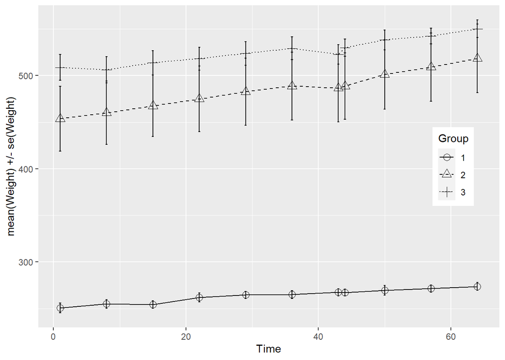

```r
# Plot the mean profiles
ggplot(ratsS, aes(x = Time, y = mean, linetype = Group, shape = Group)) +
  geom_line() +
  scale_linetype_manual(values = c(1,2,3)) +
  geom_point(size=3) +
  scale_shape_manual(values = c(1,2,3)) +
  geom_errorbar(aes(ymin=mean-se, ymax=mean+se, linetype="1"), width=0.3) +
  theme(legend.position = c(0.9,0.5)) +
  scale_y_continuous(name = "mean(Weight) +/- se(Weight)")
```

```r
rats$Time <- factor(rats$Time)

str(rats)
```

```
## tibble [176 x 6] (S3: tbl_df/tbl/data.frame)
##  $ ID       : Factor w/ 16 levels "1","2","3","4",..: 1 2 3 4 5 6 7 8 9 10 ...
##  $ Group    : Factor w/ 3 levels "1","2","3": 1 1 1 1 1 1 1 1 2 2 ...
##  $ WD       : chr [1:176] "WD1" "WD1" "WD1" "WD1" ...
##  $ Weight   : int [1:176] 240 225 245 260 255 260 275 245 410 405 ...
##  $ Time     : Factor w/ 11 levels "1","8","15","22",..: 1 1 1 1 1 1 1 1 1 1 ...
##  $ stdweight: num [1:176] -1.001 -1.12 -0.961 -0.842 -0.882 ...
```

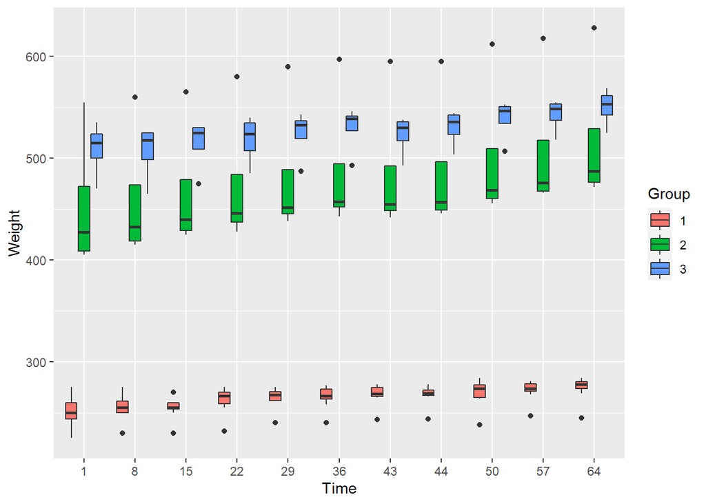

```r
ggplot(rats, aes(x = Time, y = Weight, fill = Group)) +
  geom_boxplot()
```

```r
rats$Time <- as.integer(rats$Time)

str(rats)
```

```
## tibble [176 x 6] (S3: tbl_df/tbl/data.frame)
##  $ ID       : Factor w/ 16 levels "1","2","3","4",..: 1 2 3 4 5 6 7 8 9 10 ...
##  $ Group    : Factor w/ 3 levels "1","2","3": 1 1 1 1 1 1 1 1 2 2 ...
##  $ WD       : chr [1:176] "WD1" "WD1" "WD1" "WD1" ...
##  $ Weight   : int [1:176] 240 225 245 260 255 260 275 245 410 405 ...
##  $ Time     : int [1:176] 1 1 1 1 1 1 1 1 1 1 ...
##  $ stdweight: num [1:176] -1.001 -1.12 -0.961 -0.842 -0.882 ...
```

After we have calculated means and standard errors by groups for each point, we can see from the plot that groups 2 and 3 are close to each other and their SEs seem to cross, so maybe the difference in diet for there groups does not have affect how weight changes. Group 1 again differ from other two group with markedly lower values. Group 1 also has smaller SEs as there is more observations in this group.

#### Boxplots of mean summary measures for the threet groups, with and without outliers

```r
# Create a summary data by treatment and subject with mean as the summary variable (ignoring baseline).
ratS1 <- rats  %>%
  filter(Time>1) %>%
  group_by(Group, ID) %>%
  summarise( mean=mean(Weight) ) %>%
  ungroup()
# Glimpse the data
glimpse(ratS1)
```

```
## Rows: 16
## Columns: 3
## $ Group <fct> 1, 1, 1, 1, 1, 1, 1, 1, 2, 2, 2, 2, 3, 3, 3, 3
## $ ID    <fct> 1, 2, 3, 4, 5, 6, 7, 8, 9, 10, 11, 12, 13, 14, 15, 16
## $ mean  <dbl> 263.2, 238.9, 261.7, 267.2, 270.9, 276.2, 274.6, 267.5, 443.9...
```

```r
ratS1
```

```
## # A tibble: 16 x 3
##    Group ID     mean
##    <fct> <fct> <dbl>
##  1 1     1      263.
##  2 1     2      239.
##  3 1     3      262.
##  4 1     4      267.
##  5 1     5      271.
##  6 1     6      276.
##  7 1     7      275.
##  8 1     8      268.
##  9 2     9      444.
## 10 2     10     458.
## 11 2     11     456.
## 12 2     12     594
## 13 3     13     495.
## 14 3     14     536.
## 15 3     15     542.
## 16 3     16     536.
```

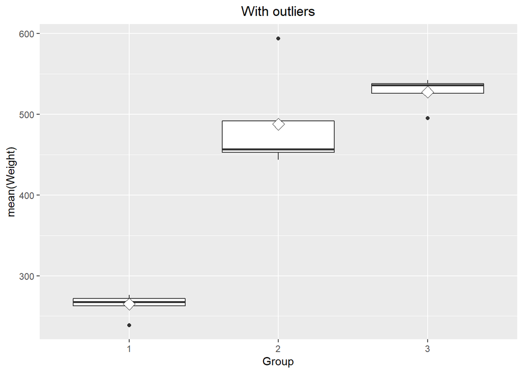

```r
# Draw a boxplot of the mean versus treatment
ggplot(ratS1, aes(x = Group, y = mean)) +
  geom_boxplot() +
  stat_summary(fun.y = "mean", geom = "point", shape=23, size=4, fill = "white") +
  scale_y_continuous(name = "mean(Weight)")+labs(title="With outliers")+theme(
  plot.title = element_text(hjust = 0.5))
```

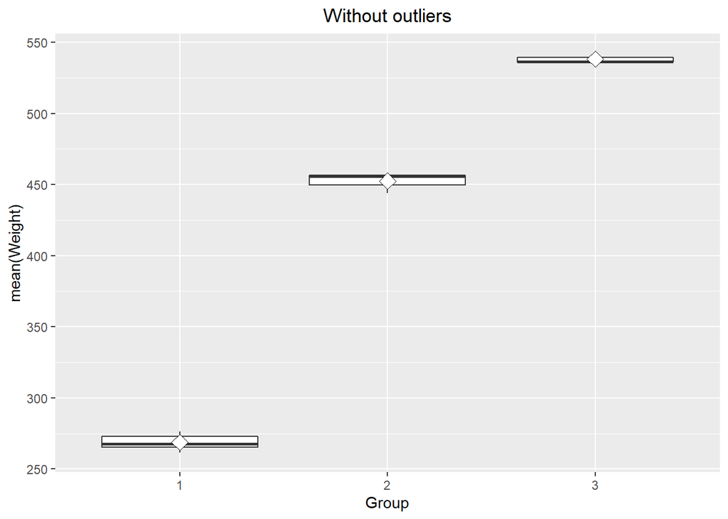

```r
# Create a new data by filtering the outlier and adjust the ggplot code the draw the plot again with the new data
ratS2 <- filter(ratS1, mean>250 & mean<550)
ratS2 <- filter(ratS2, mean!=495.2)


ggplot(ratS2, aes(x = Group, y = mean)) +
  geom_boxplot() +
  stat_summary(fun.y = "mean", geom = "point", shape=23, size=4, fill = "white") +
  scale_y_continuous(name = "mean(Weight)")+labs(title="Without outliers")+theme(
  plot.title = element_text(hjust = 0.5))
```

#### Statistical tests on mean summary measures

```r
### One way ANOVA to see if there is a difference between groups (with data without outliers)

fit1<-aov(mean ~ Group, ratS2)
summary(fit1)
```

```
##             Df Sum Sq Mean Sq F value   Pr(>F)
## Group        2 176917   88458    2836 1.69e-14 ***
## Residuals   10    312      31
## ---
## Signif. codes:  0 '***' 0.001 '**' 0.01 '*' 0.05 '.' 0.1 ' ' 1
```

```r
TukeyHSD(fit1,"Group")
```

```
##   Tukey multiple comparisons of means
##     95% family-wise confidence level
##
## Fit: aov(formula = mean ~ Group, data = ratS2)
##
## $Group
##          diff       lwr       upr p adj
## 2-1 183.64286 173.07885 194.20686     0
## 3-1 269.50952 258.94552 280.07353     0
## 3-2  85.86667  73.36717  98.36617     0
```

```r
### Adding the baseline and testing the difference between groups adjusted for the baseline (with data with outliers so we can add the baseline column)

RATS <- read.table("https://raw.githubusercontent.com/KimmoVehkalahti/MABS/master/Examples/data/rats.txt", sep="\t", header=T)

str(RATS)
```

```
## 'data.frame':    16 obs. of  13 variables:
##  $ ID   : int  1 2 3 4 5 6 7 8 9 10 ...
##  $ Group: int  1 1 1 1 1 1 1 1 2 2 ...
##  $ WD1  : int  240 225 245 260 255 260 275 245 410 405 ...
##  $ WD8  : int  250 230 250 255 260 265 275 255 415 420 ...
##  $ WD15 : int  255 230 250 255 255 270 260 260 425 430 ...
##  $ WD22 : int  260 232 255 265 270 275 270 268 428 440 ...
##  $ WD29 : int  262 240 262 265 270 275 273 270 438 448 ...
##  $ WD36 : int  258 240 265 268 273 277 274 265 443 460 ...
##  $ WD43 : int  266 243 267 270 274 278 276 265 442 458 ...
##  $ WD44 : int  266 244 267 272 273 278 271 267 446 464 ...
##  $ WD50 : int  265 238 264 274 276 284 282 273 456 475 ...
##  $ WD57 : int  272 247 268 273 278 279 281 274 468 484 ...
##  $ WD64 : int  278 245 269 275 280 281 284 278 478 496 ...
```

```r
RATS$ID <- factor(RATS$ID)
RATS$Group <- factor(RATS$Group)

# Add the baseline from the original data as a new variable to the summary data
ratS3 <- ratS1 %>%
  mutate(baseline = RATS$WD1)

str(ratS3)
```

```
## tibble [16 x 4] (S3: tbl_df/tbl/data.frame)
##  $ Group   : Factor w/ 3 levels "1","2","3": 1 1 1 1 1 1 1 1 2 2 ...
##  $ ID      : Factor w/ 16 levels "1","2","3","4",..: 1 2 3 4 5 6 7 8 9 10 ...
##  $ mean    : num [1:16] 263 239 262 267 271 ...
##  $ baseline: int [1:16] 240 225 245 260 255 260 275 245 410 405 ...
```

```r
# Fit the linear model with the mean as the response and compute the analysis of covariance table for the fitted model with anova()
fit <- lm(mean ~ baseline + Group, data = ratS3)

summary(fit)
```

```
##
## Call:
## lm(formula = mean ~ baseline + Group, data = ratS3)
##
## Residuals:
##     Min      1Q  Median      3Q     Max
## -23.905  -4.194   2.190   7.577  14.800
##
## Coefficients:
##             Estimate Std. Error t value Pr(>|t|)
## (Intercept) 33.16375   21.87657   1.516   0.1554
## baseline     0.92513    0.08572  10.793 1.56e-07 ***
## Group2      34.85753   18.82308   1.852   0.0888 .
## Group3      23.67526   23.25324   1.018   0.3287
## ---
## Signif. codes:  0 '***' 0.001 '**' 0.01 '*' 0.05 '.' 0.1 ' ' 1
##
## Residual standard error: 11.68 on 12 degrees of freedom
## Multiple R-squared:  0.9936, Adjusted R-squared:  0.992
## F-statistic: 622.1 on 3 and 12 DF,  p-value: 1.989e-13
```

```r
anova(fit)
```

```
## Analysis of Variance Table
##
## Response: mean
##           Df Sum Sq Mean Sq   F value   Pr(>F)
## baseline   1 253625  253625 1859.8201 1.57e-14 ***
## Group      2    879     439    3.2219  0.07586 .
## Residuals 12   1636     136
## ---
## Signif. codes:  0 '***' 0.001 '**' 0.01 '*' 0.05 '.' 0.1 ' ' 1
```

```r
fit2<-aov(mean ~ baseline + Group, data=ratS3)
summary(fit2)
```

```
##             Df Sum Sq Mean Sq  F value   Pr(>F)
## baseline     1 253625  253625 1859.820 1.57e-14 ***
## Group        2    879     439    3.222   0.0759 .
## Residuals   12   1636     136
## ---
## Signif. codes:  0 '***' 0.001 '**' 0.01 '*' 0.05 '.' 0.1 ' ' 1
```

```r
TukeyHSD(fit2,"Group")
```

```
##   Tukey multiple comparisons of means
##     95% family-wise confidence level
##
## Fit: aov(formula = mean ~ baseline + Group, data = ratS3)
##
## $Group
##           diff        lwr       upr     p adj
## 2-1  12.806026  -6.272296 31.884347 0.2140553
## 3-1  -4.347112 -23.425434 14.731209 0.8185859
## 3-2 -17.153138 -39.182886  4.876611 0.1364887
```

As we have now three groups we can’t run t-test so we use one-way ANOVA to see if there is a difference between groups.With the data that do not include outliers we see that there is a significant difference between groups and post-hoc Tukey-HSD test shows in pairwise comparison there is significant difference between every pair. However, after we add the baseline variable to our model, the baseline is significantly related to weight but the group variable is not significant and in the pairwise comparison we see that there is no significant difference between any pair. So we can conclude that the type of diet which rats followed do not explain the difference in mean weight measures when we had adjusted the analyses for the baseline values.

### Chapter 9 analyses on BPRS data

```r
BPRS <- read.csv("data/BPRSL.csv", header=T)

str(BPRS)
```

```
## 'data.frame':    360 obs. of  5 variables:
##  $ treatment: int  1 1 1 1 1 1 1 1 1 1 ...
##  $ subject  : int  1 2 3 4 5 6 7 8 9 10 ...
##  $ weeks    : chr  "week0" "week0" "week0" "week0" ...
##  $ bprs     : int  42 58 54 55 72 48 71 30 41 57 ...
##  $ week     : int  0 0 0 0 0 0 0 0 0 0 ...
```

```r
BPRS$subject <- factor(BPRS$subject)
BPRS$treatment <- factor(BPRS$treatment)
```

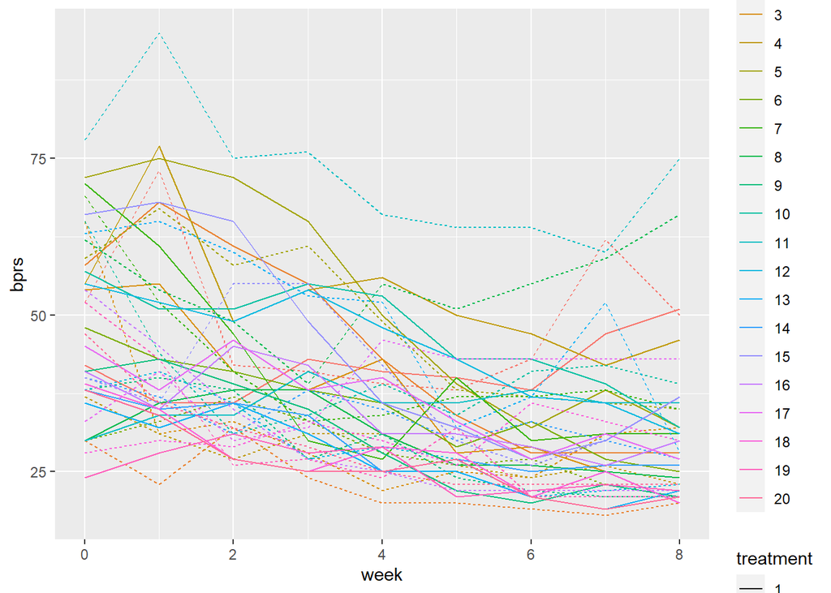

```r
library(ggplot2)

ggplot(BPRS, aes(x = week, y = bprs, colour = subject, linetype = treatment)) +
  geom_line()
```

```r
BPRS_w <- read.table("https://raw.githubusercontent.com/KimmoVehkalahti/MABS/master/Examples/data/BPRS.txt", sep=" ", header=TRUE)

str(BPRS_w)
```

```
## 'data.frame':    40 obs. of  11 variables:
##  $ treatment: int  1 1 1 1 1 1 1 1 1 1 ...
##  $ subject  : int  1 2 3 4 5 6 7 8 9 10 ...
##  $ week0    : int  42 58 54 55 72 48 71 30 41 57 ...
##  $ week1    : int  36 68 55 77 75 43 61 36 43 51 ...
##  $ week2    : int  36 61 41 49 72 41 47 38 39 51 ...
##  $ week3    : int  43 55 38 54 65 38 30 38 35 55 ...
##  $ week4    : int  41 43 43 56 50 36 27 31 28 53 ...
##  $ week5    : int  40 34 28 50 39 29 40 26 22 43 ...
##  $ week6    : int  38 28 29 47 32 33 30 26 20 43 ...
##  $ week7    : int  47 28 25 42 38 27 31 25 23 39 ...
##  $ week8    : int  51 28 24 46 32 25 31 24 21 32 ...
```

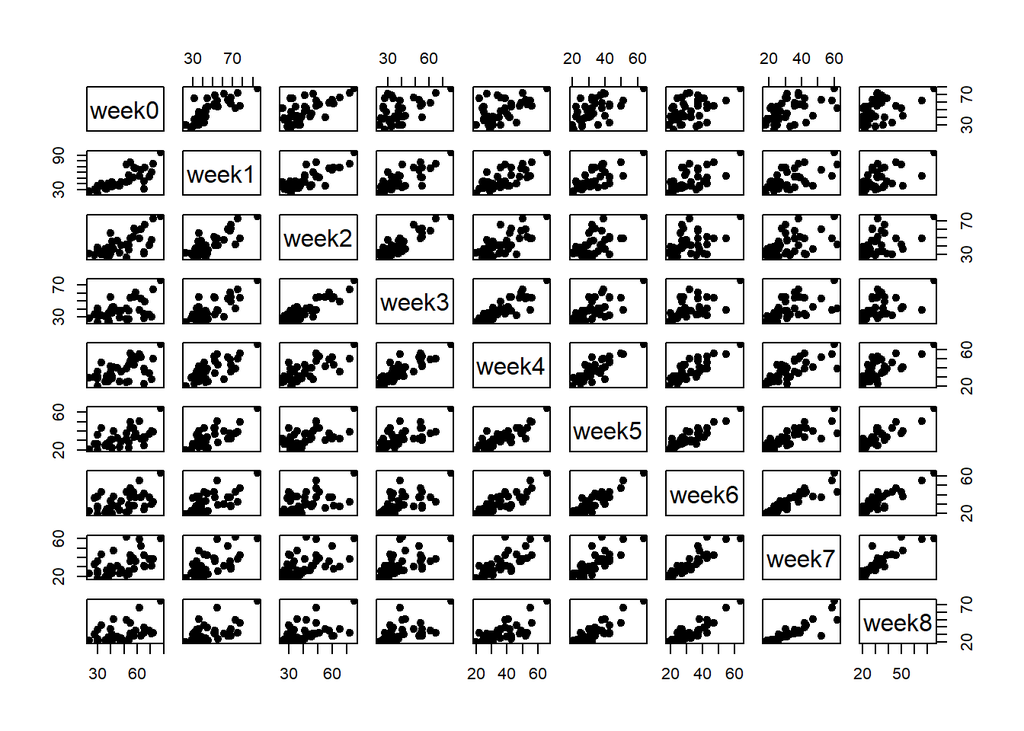

```r
pairs(BPRS_w[,3:11], pch = 19)
```

After plotting bprs over study time there seem not be a clear difference between solid and dashed lines i.e no difference between the treatment groups. From the scatterplot matrix graph we can see that there are clear patterns and as we have longitudinal data measured from same individuals at different time points, the plot demonstrates that repeated measures are not independent of one another.

```r
# Create a basic linear model
bprs_reg <- lm(bprs ~ week + treatment, data = BPRS)

# print out a summary of the model
summary(bprs_reg)
```

```
##
## Call:
## lm(formula = bprs ~ week + treatment, data = BPRS)
##
## Residuals:
##     Min      1Q  Median      3Q     Max
## -22.454  -8.965  -3.196   7.002  50.244
##
## Coefficients:
##             Estimate Std. Error t value Pr(>|t|)
## (Intercept)  46.4539     1.3670  33.982   <2e-16 ***
## week         -2.2704     0.2524  -8.995   <2e-16 ***
## treatment2    0.5722     1.3034   0.439    0.661
## ---
## Signif. codes:  0 '***' 0.001 '**' 0.01 '*' 0.05 '.' 0.1 ' ' 1
##
## Residual standard error: 12.37 on 357 degrees of freedom
## Multiple R-squared:  0.1851, Adjusted R-squared:  0.1806
## F-statistic: 40.55 on 2 and 357 DF,  p-value: < 2.2e-16
```

```r
library(lme4)
# Create a random intercept model
bprs_ref <- lmer(bprs ~ week + treatment + (1 | subject), data = BPRS, REML = FALSE)

# Print the summary of the model
summary(bprs_ref)
```

```
## Linear mixed model fit by maximum likelihood  ['lmerMod']
## Formula: bprs ~ week + treatment + (1 | subject)
##    Data: BPRS
##
##      AIC      BIC   logLik deviance df.resid
##   2748.7   2768.1  -1369.4   2738.7      355
##
## Scaled residuals:
##     Min      1Q  Median      3Q     Max
## -3.0481 -0.6749 -0.1361  0.4813  3.4855
##
## Random effects:
##  Groups   Name        Variance Std.Dev.
##  subject  (Intercept)  47.41    6.885
##  Residual             104.21   10.208
## Number of obs: 360, groups:  subject, 20
##
## Fixed effects:
##             Estimate Std. Error t value
## (Intercept)  46.4539     1.9090  24.334
## week         -2.2704     0.2084 -10.896
## treatment2    0.5722     1.0761   0.532
##
## Correlation of Fixed Effects:
##            (Intr) week
## week       -0.437
## treatment2 -0.282  0.000
```

```r
# Create a random intercept and random slope model
bprs_ref1 <- lmer(bprs ~ week + treatment + (week | subject), data = BPRS, REML = FALSE)

# print a summary of the model
summary(bprs_ref1)
```

```
## Linear mixed model fit by maximum likelihood  ['lmerMod']
## Formula: bprs ~ week + treatment + (week | subject)
##    Data: BPRS
##
##      AIC      BIC   logLik deviance df.resid
##   2745.4   2772.6  -1365.7   2731.4      353
##
## Scaled residuals:
##     Min      1Q  Median      3Q     Max
## -2.8919 -0.6194 -0.0691  0.5531  3.7976
##
## Random effects:
##  Groups   Name        Variance Std.Dev. Corr
##  subject  (Intercept) 64.8222  8.0512
##           week         0.9609  0.9802   -0.51
##  Residual             97.4305  9.8707
## Number of obs: 360, groups:  subject, 20
##
## Fixed effects:
##             Estimate Std. Error t value
## (Intercept)  46.4539     2.1052  22.066
## week         -2.2704     0.2977  -7.626
## treatment2    0.5722     1.0405   0.550
##
## Correlation of Fixed Effects:
##            (Intr) week
## week       -0.582
## treatment2 -0.247  0.000
```

```r
# perform an ANOVA test on the two models
anova(bprs_ref1, bprs_ref)
```

```
## Data: BPRS
## Models:
## bprs_ref: bprs ~ week + treatment + (1 | subject)
## bprs_ref1: bprs ~ week + treatment + (week | subject)
##           npar    AIC    BIC  logLik deviance  Chisq Df Pr(>Chisq)
## bprs_ref     5 2748.7 2768.1 -1369.4   2738.7
## bprs_ref1    7 2745.4 2772.6 -1365.7   2731.4 7.2721  2    0.02636 *
## ---
## Signif. codes:  0 '***' 0.001 '**' 0.01 '*' 0.05 '.' 0.1 ' ' 1
```

```r
# Create a random intercept and random slope model with the interaction
bprs_ref2 <- lmer(bprs ~ week + treatment + week*treatment+ (week | subject), data = BPRS, REML = FALSE)

# print a summary of the model
summary(bprs_ref2)
```

```
## Linear mixed model fit by maximum likelihood  ['lmerMod']
## Formula: bprs ~ week + treatment + week * treatment + (week | subject)
##    Data: BPRS
##
##      AIC      BIC   logLik deviance df.resid
##   2744.3   2775.4  -1364.1   2728.3      352
##
## Scaled residuals:
##     Min      1Q  Median      3Q     Max
## -3.0512 -0.6271 -0.0768  0.5288  3.9260
##
## Random effects:
##  Groups   Name        Variance Std.Dev. Corr
##  subject  (Intercept) 64.9964  8.0620
##           week         0.9687  0.9842   -0.51
##  Residual             96.4707  9.8220
## Number of obs: 360, groups:  subject, 20
##
## Fixed effects:
##                 Estimate Std. Error t value
## (Intercept)      47.8856     2.2521  21.262
## week             -2.6283     0.3589  -7.323
## treatment2       -2.2911     1.9090  -1.200
## week:treatment2   0.7158     0.4010   1.785
##
## Correlation of Fixed Effects:
##             (Intr) week   trtmn2
## week        -0.650
## treatment2  -0.424  0.469
## wek:trtmnt2  0.356 -0.559 -0.840
```

```r
# perform an ANOVA test on the two models
anova(bprs_ref2, bprs_ref1)
```

```
## Data: BPRS
## Models:
## bprs_ref1: bprs ~ week + treatment + (week | subject)
## bprs_ref2: bprs ~ week + treatment + week * treatment + (week | subject)
##           npar    AIC    BIC  logLik deviance  Chisq Df Pr(>Chisq)
## bprs_ref1    7 2745.4 2772.6 -1365.7   2731.4
## bprs_ref2    8 2744.3 2775.4 -1364.1   2728.3 3.1712  1    0.07495 .
## ---
## Signif. codes:  0 '***' 0.001 '**' 0.01 '*' 0.05 '.' 0.1 ' ' 1
```

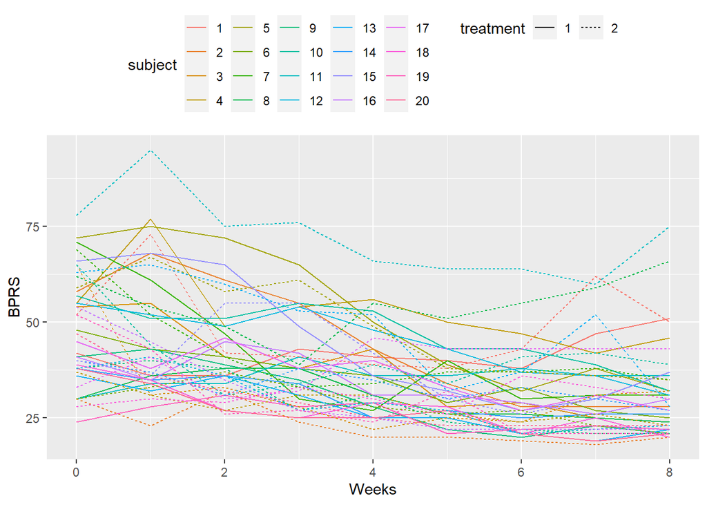

```r
# draw the plot of RATSL with the observed Weight values
ggplot(BPRS, aes(x = week, y = bprs, colour = subject)) +
  geom_line(aes(linetype = treatment)) +
  scale_x_continuous(name = "Weeks") +
  scale_y_continuous(name = "BPRS") +
  theme(legend.position = "top")
```

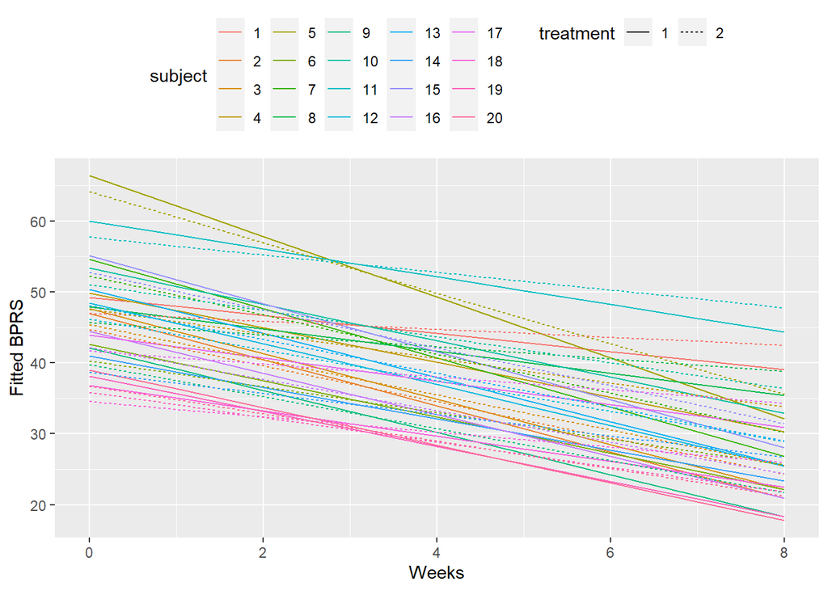

```r
# Create a vector of the fitted values
Fitted <- fitted(bprs_ref2)

# Create a new column fitted to RATSL
BPRS <- BPRS %>% mutate(fit=Fitted %>% as.numeric())

# draw the plot of RATSL with the Fitted values of weight
ggplot(BPRS, aes(x = week, y = fit, colour = subject)) +
  geom_line(aes(linetype = treatment)) +
  scale_x_continuous(name = "Weeks") +
  scale_y_continuous(name = "Fitted BPRS") +
  theme(legend.position = "top")
```

After we have fitted a basic linear model, we can see that there seem to be no treatment effect as the coefficient for treatment is not significant, however the week variable seem to be significantly related to BSPR.

Next we fit a random intercept model that allows the linear regression fits for each individual differ in intercept. The estimates results are quite similar as in the basic linear model with some small difference in the standard errors. Again, there is no evidence of the treatment effect. The estimated variance for subject random effects is not quite large so there is probably not much variation in intercepts of the regressions fits of the individual BSPR changes.

We proceed to fit a random intercept and random slope model. Now we also allow the regression fits for each individual differ in slope. Again there is no evidence of treatment effect, the estimates are again similar to previous models. However, according the likelihood ratio test the random intercept and slope model is a better fit than the random intercept model (p-value 0.026 ).

Finally we fit a random intercept and random slope model with week*treatment interaction term. Now the estimates are somewhat diffrent. However, coefficients for the treatment variable or for the interaction term are not statistically significant. Also, when we compare the random intercept and slope model with interaction term to a model without interaction term, it seems that the interaction model is no better fit than the model without the interaction term.

Plotting the fitted values also shows that it is very hard to see any difference between the two tretment groups.